[figure not shown]

# **Taller semana 6:** XGBoost

**Semana 6 - Taller sumativo -** Estimación de incumplimiento de clientes bancarios

**Profesor:** *Fernando Lozano* - **Autor Notebook:** *Daniel Felipe López*

## Introducción

### Descripción

Este *jupyter notebook* contiene el material necesario para el desarrollo del Taller de la Semana 6 del curso *MLS: Machine learning supervisado*. En esta tarea usted verá la solución a un problema de clasificación con la técnica de métodos de combinacion de modelos Xgboost.

#### Objetivos de Aprendizaje

Aplicar técnicas de métodos de combinacion de modelos para resolver problemas de clasificación.

### Teoría

#### XGBoost

XGBoost es un algoritmo de aprendizaje automático, que combina varios modelos más débiles para formar un modelo más fuerte y preciso. Para esto, XGBoost utiliza árboles de decisión como modelos base, usa regularización y optimización de la construcción de arboles. Un par de parámetros importantes son:

- El parámetro max_depth en XGBoost controla la profundidad máxima de cada árbol de decisión. Limitar la profundidad ayuda a prevenir el sobreajuste al restringir la complejidad del árbol. El parámetro es un entero con rango entre [1, $\infty$] y el valor por defecto es 6.
- El parámetro n_estimators especifica el número de árbole1s que se construirán en el ensamblaje. Cada árbol se construye secuencialmente, y un mayor número de estimadores permite un modelo más preciso, ya que se agregan más estimaciones al ensamblaje, aunque también aumenta la carga computacional. El rango posible es entero entre [0, $\infty$] y el valor por defecto es 100.
- El parámetro learning_rate controla el encogimiento de los pesos de los datos de los nuevos modelos para hacer el modelo más conservativo. El rango es de [0,1] y el valor por defecto en XGBoost es 0.3.
- El parámetro reg_lambda controla la regularizacion L2 que usa el modelo. Aumentar el valor hace el modelo más conservativo. El rango posible es de [0, $\infty$] y el valor por defecto es 1.

# Problema y conjunto de datos

El problema consiste en predecir si un software va a tener fallas, basado en las características de Maccabe y Halstead del código. El conjunto de datos fue extraido de https://kaggle.com/competitions/playground-series-s3e23. Para ver una descripcción detallada e información sobre las variables, ver aquí, en especial, la sección sobre notas sobre Mccabe/Halstead.

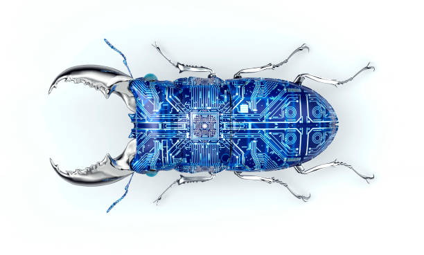

Citación: Walter Reade, Ashley Chow. (2023). Binary Classification with a Software Defects Dataset. Kaggle. https://kaggle.com/competitions/playground-series-s3e23

# Metodología

En éste cuaderno encontrará un ejercicio práctico paso a paso. Realice la solución a cada uno de los puntos propuestos y explique claramente su procedimiento con comentarios en el código y celdas tipo Markdown. Para esto, complete las céldas de código marcadas con el siguiente comentario:

```
# =====================================================
# COMPLETAR ===========================================
#

# =====================================================
```

```python
#Importar librerias necesarias
import numpy as np
import pandas as pd
pd.set_option('display.max_columns', 100);
import seaborn as sns
import time
from random import random, seed
import matplotlib.pyplot as plt
import seaborn as sns
%matplotlib inline

from scipy.stats import uniform, randint
from sklearn.preprocessing import MinMaxScaler, RobustScaler, LabelEncoder, OneHotEncoder
from random import random, seed
from sklearn.model_selection import RandomizedSearchCV, GridSearchCV, train_test_split, KFold, cross_validate, cross_val_predict, cross_val_score, StratifiedKFold
from sklearn.metrics import confusion_matrix, accuracy_score , average_precision_score, f1_score, ConfusionMatrixDisplay, classification_report
from sklearn.ensemble import RandomForestClassifier
from sklearn.utils.class_weight import compute_class_weight
import xgboost as xgb
from xgboost.sklearn import XGBClassifier
from xgboost import plot_importance

import warnings # Ignorar las warnings
warnings.filterwarnings("ignore")
```

```python
#Leer la base de datos
df = pd.read_csv("train.csv").reset_index(drop=True)
```

```python
df.head()
```

|  | id | loc | v(g) | ev(g) | iv(g) | n | v | l | d | i | e | b | t | lOCode | lOComment | lOBlank | locCodeAndComment | uniq_Op | uniq_Opnd | total_Op | total_Opnd | branchCount | defects |
| --- | --- | --- | --- | --- | --- | --- | --- | --- | --- | --- | --- | --- | --- | --- | --- | --- | --- | --- | --- | --- | --- | --- | --- |
| 0 | 0 | 22.0 | 3.0 | 1.0 | 2.0 | 60.0 | 278.63 | 0.06 | 19.56 | 14.25 | 5448.79 | 0.09 | 302.71 | 17 | 1 | 1 | 0 | 16.0 | 9.0 | 38.0 | 22.0 | 5.0 | False |
| 1 | 1 | 14.0 | 2.0 | 1.0 | 2.0 | 32.0 | 151.27 | 0.14 | 7.00 | 21.11 | 936.71 | 0.05 | 52.04 | 11 | 0 | 1 | 0 | 11.0 | 11.0 | 18.0 | 14.0 | 3.0 | False |
| 2 | 2 | 11.0 | 2.0 | 1.0 | 2.0 | 45.0 | 197.65 | 0.11 | 8.05 | 22.76 | 1754.01 | 0.07 | 97.45 | 8 | 0 | 1 | 0 | 12.0 | 11.0 | 28.0 | 17.0 | 3.0 | False |
| 3 | 3 | 8.0 | 1.0 | 1.0 | 1.0 | 23.0 | 94.01 | 0.19 | 5.25 | 17.86 | 473.66 | 0.03 | 26.31 | 4 | 0 | 2 | 0 | 8.0 | 6.0 | 16.0 | 7.0 | 1.0 | True |
| 4 | 4 | 11.0 | 2.0 | 1.0 | 2.0 | 17.0 | 60.94 | 0.18 | 5.63 | 12.44 | 365.67 | 0.02 | 20.31 | 7 | 0 | 2 | 0 | 7.0 | 6.0 | 10.0 | 10.0 | 3.0 | False |

```python
#Mapa para transformar la variable objetivo
target_map={
    False:0,
    True: 1
}

# Separación de variable objetivo y variables explicativas
X = df.loc[:, df.columns != 'defects']
y = df['defects']

# Aplicar el reemplazo
y_numeric = np.array(y.replace(target_map))
```

```python
y.shape
```

```
(101763,)
```

```
 [Text(-0.8327451950972532, 0.7187040002966714, 'False'),
 [Text(-0.45422465187122896, 0.39202036379818433, '77.3%'),
```

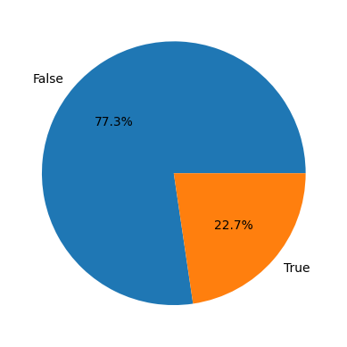

```python
#Observar balance de clases

#Contar y normalizar
dfsizes = y.value_counts()/y.shape[0]
#Crear figura
fig, ax = plt.subplots()
#Pintar
ax.pie(list(dfsizes),labels=list(dfsizes.index) ,autopct='%1.1f%%')
```

# Modelo XGBoost básico

```python
# Inicializar el modelo xgboost
model = xgb.XGBClassifier()
# Inicializar el instrumento de cross validation
kfold = StratifiedKFold(n_splits=5, shuffle=True, random_state=52)
# Establecer métricas de evaluación
scoring = ['accuracy','precision', 'recall', 'f1']
# Realizar scores
scores = cross_validate(model, X, y, cv=kfold, scoring=scoring, verbose = 10, n_jobs=-1)
```

```
[Parallel(n_jobs=-1)]: Using backend LokyBackend with 16 concurrent workers.
```

```
[CV] START .....................................................................
[CV] START .....................................................................
[CV] START .....................................................................
[CV] START .....................................................................
[CV] START .....................................................................
[CV] END  accuracy: (test=0.812) f1: (test=0.475) precision: (test=0.648) recall: (test=0.375) total time=   1.2s
[CV] END  accuracy: (test=0.809) f1: (test=0.468) precision: (test=0.636) recall: (test=0.370) total time=   1.2s
[CV] END  accuracy: (test=0.811) f1: (test=0.480) precision: (test=0.636) recall: (test=0.386) total time=   1.2s
[CV] END  accuracy: (test=0.809) f1: (test=0.478) precision: (test=0.630) recall: (test=0.385) total time=   1.2s
[CV] END  accuracy: (test=0.811) f1: (test=0.475) precision: (test=0.639) recall: (test=0.378) total time=   1.2s
```

```
[Parallel(n_jobs=-1)]: Done   2 out of   5 | elapsed:    3.0s remaining:    4.6s
[Parallel(n_jobs=-1)]: Done   3 out of   5 | elapsed:    3.0s remaining:    2.0s
[Parallel(n_jobs=-1)]: Done   5 out of   5 | elapsed:    3.2s finished
```

```python
display(pd.DataFrame(scores))
print("Accuracy: %.2f%% (%.2f%%)" % (scores['test_accuracy'].mean()*100, scores['test_accuracy'].std()*100))
```

|  | fit_time | score_time | test_accuracy | test_precision | test_recall | test_f1 |
| --- | --- | --- | --- | --- | --- | --- |
| 0 | 1.128154 | 0.066407 | 0.810790 | 0.636169 | 0.385866 | 0.480367 |
| 1 | 1.080740 | 0.069330 | 0.812165 | 0.647719 | 0.375461 | 0.475367 |
| 2 | 1.111487 | 0.066555 | 0.809365 | 0.636499 | 0.370475 | 0.468347 |
| 3 | 1.115725 | 0.067819 | 0.809404 | 0.630011 | 0.385082 | 0.477998 |
| 4 | 1.158870 | 0.068176 | 0.810633 | 0.639062 | 0.378062 | 0.475075 |

```
Accuracy: 81.05% (0.10%)
```

# Ejercicio: Mejora del modelo básico

- El objetivo de este ejercicio es mejorar el modelo de XGBoost propuesto anteriormente. Para esto, implemente una búsqueda aleatoria o una búsqueda por red para encontrar mejores parámetros. Utilice el objeto kfold anterior para utilizar los mísmos datos en el entrenamiento de los modelos (Máximo 100 fits, usando n_jobs = -1 para paralelización).
- Compare el mejor modelo con el modelo inicial en cuanto a estadísticas de clasificación y tiempo de ejecución. De sus conclusiones al respecto, relacionado con el papel de cada parámetro en su búsqueda.
- Implemente costos respecto a la presencia de las clases en el conjunto de datos para el mejor modelo sintonizado y compare con el mismo modelo sin costos. De sus conclusiones.

## Búsqueda

A continuación, encontrará una función que le ayudará a visualizar los resultados de cada modelo incluyendo los parámetros usados.

```python
def report_best_scores(results, n_top=3):
    # Esta función espera una instancia de resultados de búsqueda de cross validation, por ejemplo: search.cv_results_
    for i in range(1, n_top + 1):
        candidates = np.flatnonzero(results['rank_test_accuracy'] == i)
        for candidate in candidates:
            print("Model with rank: {0}".format(i))
            print("Mean validation score: {0:.3f} (std: {1:.3f})".format(
                  results['mean_test_accuracy'][candidate],
                  results['std_test_accuracy'][candidate]))
            print("Parameters: {0}".format(results['params'][candidate]))
            print("")
    # Retorna los parámetros del mejor modelo basado en accuracy.
    return list(results.sort_values("rank_test_accuracy")['params'])[0]

def see_results(results):
    # Esta función espera una instancia de pandas dataframe de los resultados de búsqueda de cross validation, por ejemplo: pd.DataFrame(search.cv_results_)
    display(results[results.columns.drop(list(results.filter(regex='split')))].sort_values("rank_test_accuracy"))
```

```python
# =====================================================
# COMPLETAR ===========================================
#

# Definir parámetros (una forma de hacer esto es con las funciones uniform y randint)

# Inicializar la búsqueda aleatoria con el kfold definido anteriormente y con n_jobs = -1

# Realizar el fit
# your code here

#Definir un espacio de busqueda para los hiperparametros
param_dist = {'n_estimators' : randint(50, 200),
              'max_depth' : randint(5, 20),
              'learning_rate' : uniform(loc=0.01, scale=1),
              'reg_lambda' : uniform(loc=0.1, scale=2)
            }

model2 = xgb.XGBClassifier()
scoring = ['accuracy','precision', 'recall', 'f1']
rand_search = RandomizedSearchCV(estimator=model2, cv=kfold, scoring=scoring, random_state=42, n_jobs=1,
                                param_distributions=param_dist, n_iter=20, refit='f1', verbose=10)
search = rand_search.fit(X, y)


# =====================================================
resultados = pd.DataFrame(search.cv_results_)
see_results(resultados)
best_model_params = report_best_scores(resultados)
best_model_params
```

```
Fitting 5 folds for each of 20 candidates, totalling 100 fits
[CV 1/5; 1/20] START learning_rate=0.3845401188473625, max_depth=17, n_estimators=64, reg_lambda=1.5639878836228103
[CV 1/5; 1/20] END learning_rate=0.3845401188473625, max_depth=17, n_estimators=64, reg_lambda=1.5639878836228103; accuracy: (test=0.803) f1: (test=0.477) precision: (test=0.597) recall: (test=0.396) total time=   4.0s
[CV 2/5; 1/20] START learning_rate=0.3845401188473625, max_depth=17, n_estimators=64, reg_lambda=1.5639878836228103
[CV 2/5; 1/20] END learning_rate=0.3845401188473625, max_depth=17, n_estimators=64, reg_lambda=1.5639878836228103; accuracy: (test=0.799) f1: (test=0.457) precision: (test=0.589) recall: (test=0.374) total time=   4.1s
[CV 3/5; 1/20] START learning_rate=0.3845401188473625, max_depth=17, n_estimators=64, reg_lambda=1.5639878836228103
[CV 3/5; 1/20] END learning_rate=0.3845401188473625, max_depth=17, n_estimators=64, reg_lambda=1.5639878836228103; accuracy: (test=0.797) f1: (test=0.456) precision: (test=0.581) recall: (test=0.376) total time=   3.9s
[CV 4/5; 1/20] START learning_rate=0.3845401188473625, max_depth=17, n_estimators=64, reg_lambda=1.5639878836228103
[CV 4/5; 1/20] END learning_rate=0.3845401188473625, max_depth=17, n_estimators=64, reg_lambda=1.5639878836228103; accuracy: (test=0.797) f1: (test=0.461) precision: (test=0.578) recall: (test=0.384) total time=   3.2s
[CV 5/5; 1/20] START learning_rate=0.3845401188473625, max_depth=17, n_estimators=64, reg_lambda=1.5639878836228103
[CV 5/5; 1/20] END learning_rate=0.3845401188473625, max_depth=17, n_estimators=64, reg_lambda=1.5639878836228103; accuracy: (test=0.798) f1: (test=0.458) precision: (test=0.586) recall: (test=0.376) total time=   3.8s
[CV 1/5; 2/20] START learning_rate=0.6086584841970366, max_depth=11, n_estimators=171, reg_lambda=0.41198904067240527
[CV 1/5; 2/20] END learning_rate=0.6086584841970366, max_depth=11, n_estimators=171, reg_lambda=0.41198904067240527; accuracy: (test=0.784) f1: (test=0.449) precision: (test=0.533) recall: (test=0.387) total time=   4.3s
[CV 2/5; 2/20] START learning_rate=0.6086584841970366, max_depth=11, n_estimators=171, reg_lambda=0.41198904067240527
[CV 2/5; 2/20] END learning_rate=0.6086584841970366, max_depth=11, n_estimators=171, reg_lambda=0.41198904067240527; accuracy: (test=0.786) f1: (test=0.447) precision: (test=0.540) recall: (test=0.382) total time=   2.2s
[CV 3/5; 2/20] START learning_rate=0.6086584841970366, max_depth=11, n_estimators=171, reg_lambda=0.41198904067240527
[CV 3/5; 2/20] END learning_rate=0.6086584841970366, max_depth=11, n_estimators=171, reg_lambda=0.41198904067240527; accuracy: (test=0.786) f1: (test=0.447) precision: (test=0.538) recall: (test=0.383) total time=   2.9s
[CV 4/5; 2/20] START learning_rate=0.6086584841970366, max_depth=11, n_estimators=171, reg_lambda=0.41198904067240527
[CV 4/5; 2/20] END learning_rate=0.6086584841970366, max_depth=11, n_estimators=171, reg_lambda=0.41198904067240527; accuracy: (test=0.786) f1: (test=0.455) precision: (test=0.538) recall: (test=0.393) total time=   2.6s
[CV 5/5; 2/20] START learning_rate=0.6086584841970366, max_depth=11, n_estimators=171, reg_lambda=0.41198904067240527
[CV 5/5; 2/20] END learning_rate=0.6086584841970366, max_depth=11, n_estimators=171, reg_lambda=0.41198904067240527; accuracy: (test=0.786) f1: (test=0.449) precision: (test=0.538) recall: (test=0.385) total time=   2.7s
[CV 1/5; 3/20] START learning_rate=0.06808361216819946, max_depth=12, n_estimators=166, reg_lambda=1.3022300234864177
[CV 1/5; 3/20] END learning_rate=0.06808361216819946, max_depth=12, n_estimators=166, reg_lambda=1.3022300234864177; accuracy: (test=0.809) f1: (test=0.479) precision: (test=0.627) recall: (test=0.387) total time=   4.1s
[CV 2/5; 3/20] START learning_rate=0.06808361216819946, max_depth=12, n_estimators=166, reg_lambda=1.3022300234864177
[CV 2/5; 3/20] END learning_rate=0.06808361216819946, max_depth=12, n_estimators=166, reg_lambda=1.3022300234864177; accuracy: (test=0.812) f1: (test=0.476) precision: (test=0.645) recall: (test=0.377) total time=   3.8s
[CV 3/5; 3/20] START learning_rate=0.06808361216819946, max_depth=12, n_estimators=166, reg_lambda=1.3022300234864177
```

[output cut: 175 more lines]

|  | mean_fit_time | std_fit_time | mean_score_time | std_score_time | param_learning_rate | param_max_depth | param_n_estimators | param_reg_lambda | params | mean_test_accuracy | std_test_accuracy | rank_test_accuracy | mean_test_precision | std_test_precision | rank_test_precision | mean_test_recall | std_test_recall | rank_test_recall | mean_test_f1 | std_test_f1 | rank_test_f1 |
| --- | --- | --- | --- | --- | --- | --- | --- | --- | --- | --- | --- | --- | --- | --- | --- | --- | --- | --- | --- | --- | --- |
| 18 | 1.784589 | 0.203515 | 0.036451 | 0.002439 | 0.098493 | 11 | 89 | 1.789068 | {'learning_rate': 0.09849250205191949, 'max_de... | 0.811307 | 0.001574 | 1 | 0.640135 | 0.007852 | 1 | 0.382718 | 0.005830 | 11 | 0.478981 | 0.004469 | 1 |
| 7 | 7.310641 | 0.824094 | 0.045267 | 0.006320 | 0.056666 | 16 | 64 | 1.012140 | {'learning_rate': 0.05666566321361543, 'max_de... | 0.809990 | 0.002018 | 2 | 0.639632 | 0.010096 | 2 | 0.370578 | 0.004905 | 20 | 0.469224 | 0.004431 | 4 |
| 2 | 4.093054 | 0.474235 | 0.059937 | 0.005806 | 0.068084 | 12 | 166 | 1.302230 | {'learning_rate': 0.06808361216819946, 'max_de... | 0.809725 | 0.000998 | 3 | 0.632744 | 0.006216 | 3 | 0.382718 | 0.004663 | 12 | 0.476902 | 0.002443 | 2 |
| 6 | 0.850723 | 0.590674 | 0.029433 | 0.001374 | 0.441945 | 5 | 108 | 0.899722 | {'learning_rate': 0.4419450186421158, 'max_dep... | 0.808192 | 0.002500 | 4 | 0.628497 | 0.010474 | 4 | 0.376171 | 0.007548 | 18 | 0.470591 | 0.007195 | 3 |
| 5 | 4.449185 | 0.583703 | 0.047827 | 0.005052 | 0.193405 | 16 | 107 | 1.149513 | {'learning_rate': 0.19340450985343383, 'max_de... | 0.804467 | 0.001765 | 5 | 0.610051 | 0.008463 | 5 | 0.380940 | 0.004820 | 14 | 0.468954 | 0.003269 | 5 |
| 10 | 0.801700 | 0.137096 | 0.033565 | 0.001605 | 0.460499 | 6 | 181 | 1.984404 | {'learning_rate': 0.460499251969543, 'max_dept... | 0.803288 | 0.001468 | 6 | 0.606729 | 0.005799 | 6 | 0.375607 | 0.009690 | 19 | 0.463889 | 0.007388 | 6 |
| 12 | 5.586796 | 0.414627 | 0.059798 | 0.008580 | 0.240894 | 16 | 160 | 1.466527 | {'learning_rate': 0.240893825622149, 'max_dept... | 0.801549 | 0.000542 | 7 | 0.598691 | 0.002002 | 7 | 0.377341 | 0.004889 | 17 | 0.462895 | 0.003616 | 7 |
| 14 | 3.184370 | 0.407825 | 0.050898 | 0.005198 | 0.268780 | 12 | 181 | 0.723422 | {'learning_rate': 0.2687799816000169, 'max_dep... | 0.799947 | 0.001420 | 8 | 0.591892 | 0.005528 | 8 | 0.377992 | 0.003462 | 16 | 0.461341 | 0.003396 | 9 |
| 0 | 3.770569 | 0.305454 | 0.042913 | 0.005676 | 0.384540 | 17 | 64 | 1.563988 | {'learning_rate': 0.3845401188473625, 'max_dep... | 0.798797 | 0.002058 | 9 | 0.586355 | 0.006618 | 10 | 0.381070 | 0.008411 | 13 | 0.461896 | 0.007534 | 8 |
| 9 | 0.867047 | 0.244225 | 0.035139 | 0.005545 | 0.602415 | 7 | 100 | 1.460615 | {'learning_rate': 0.6024145688620425, 'max_dep... | 0.798758 | 0.002047 | 10 | 0.586951 | 0.006617 | 9 | 0.378295 | 0.010988 | 15 | 0.459991 | 0.009110 | 10 |
| 13 | 1.761237 | 0.107320 | 0.041782 | 0.007627 | 0.619997 | 12 | 84 | 1.918641 | {'learning_rate': 0.6199966577826209, 'max_dep... | 0.790061 | 0.002010 | 11 | 0.552695 | 0.007043 | 11 | 0.387270 | 0.004892 | 4 | 0.455383 | 0.003744 | 11 |
| 19 | 3.631970 | 0.131124 | 0.049847 | 0.008034 | 0.757320 | 19 | 102 | 1.273502 | {'learning_rate': 0.7573201101373809, 'max_dep... | 0.788744 | 0.001800 | 12 | 0.548046 | 0.005825 | 12 | 0.387400 | 0.003312 | 3 | 0.453925 | 0.004056 | 12 |
| 15 | 1.905279 | 0.206469 | 0.035366 | 0.004335 | 0.530068 | 14 | 53 | 0.469709 | {'learning_rate': 0.5300680211778108, 'max_dep... | 0.788381 | 0.001817 | 13 | 0.547132 | 0.006101 | 13 | 0.385319 | 0.009314 | 10 | 0.452107 | 0.006706 | 13 |
| 3 | 1.659078 | 0.355429 | 0.036804 | 0.006287 | 0.718073 | 10 | 102 | 2.039820 | {'learning_rate': 0.7180725777960455, 'max_dep... | 0.785796 | 0.001453 | 14 | 0.537993 | 0.004423 | 14 | 0.388614 | 0.006367 | 2 | 0.451242 | 0.005280 | 14 |
| 1 | 2.893973 | 0.722611 | 0.051084 | 0.009436 | 0.608658 | 11 | 171 | 0.411989 | {'learning_rate': 0.6086584841970366, 'max_dep... | 0.785570 | 0.000668 | 15 | 0.537530 | 0.002250 | 16 | 0.386100 | 0.004095 | 8 | 0.449385 | 0.002668 | 16 |
| 17 | 4.173522 | 0.322943 | 0.062564 | 0.010132 | 0.904827 | 18 | 144 | 1.943748 | {'learning_rate': 0.9048273504276488, 'max_dep... | 0.785570 | 0.003403 | 16 | 0.537632 | 0.010989 | 15 | 0.386186 | 0.007348 | 7 | 0.449449 | 0.007536 | 15 |
| 8 | 1.654800 | 0.591020 | 0.035895 | 0.001360 | 0.795176 | 7 | 157 | 1.128469 | {'learning_rate': 0.7951759613930136, 'max_dep... | 0.783517 | 0.002176 | 17 | 0.530923 | 0.007260 | 17 | 0.386576 | 0.008017 | 6 | 0.447309 | 0.005142 | 18 |
| 11 | 2.144106 | 0.336836 | 0.033105 | 0.001262 | 0.573288 | 14 | 58 | 0.131933 | {'learning_rate': 0.5732882178455393, 'max_dep... | 0.783281 | 0.001599 | 18 | 0.529889 | 0.005133 | 18 | 0.388701 | 0.003391 | 1 | 0.448429 | 0.003091 | 17 |
| 16 | 2.449419 | 0.044693 | 0.041549 | 0.003913 | 0.979585 | 14 | 93 | 1.978998 | {'learning_rate': 0.9795846277645586, 'max_dep... | 0.781423 | 0.001443 | 19 | 0.524173 | 0.004344 | 19 | 0.385926 | 0.006929 | 9 | 0.444522 | 0.005503 | 19 |
| 4 | 2.105096 | 0.130832 | 0.047350 | 0.005219 | 0.842443 | 10 | 179 | 0.463650 | {'learning_rate': 0.8424426408004217, 'max_dep... | 0.776107 | 0.003251 | 20 | 0.508077 | 0.009615 | 20 | 0.387227 | 0.005907 | 5 | 0.439460 | 0.006282 | 20 |

```
Model with rank: 1
Mean validation score: 0.811 (std: 0.002)
Parameters: {'learning_rate': np.float64(0.09849250205191949), 'max_depth': 11, 'n_estimators': 89, 'reg_lambda': np.float64(1.7890676973563029)}

Model with rank: 2
Mean validation score: 0.810 (std: 0.002)
Parameters: {'learning_rate': np.float64(0.05666566321361543), 'max_depth': 16, 'n_estimators': 64, 'reg_lambda': np.float64(1.012139968434072)}

Model with rank: 3
Mean validation score: 0.810 (std: 0.001)
Parameters: {'learning_rate': np.float64(0.06808361216819946), 'max_depth': 12, 'n_estimators': 166, 'reg_lambda': np.float64(1.3022300234864177)}
```

```
{'learning_rate': np.float64(0.09849250205191949),
 'max_depth': 11,
 'n_estimators': 89,
 'reg_lambda': np.float64(1.7890676973563029)}
```

#### Parámetros optimizados

Se utilizó una búsqueda random de parámetros con `RandomizedSearchCV` probando diferentes valores.

**1. n_estimators (50-200)**

Controla el número de árboles del modelo, valores más altos pueden mejorar el desempeño del modelo capturando patrones más complejos en los datos pero aumentaría el tiempo de ejecución. El valor óptimo encontrado fue de 89

**2. max_depth (5-20)**

Controlan la profundidad de los árboles. Valores muy altos pueden resultar en un sobreajuste por lo que hay que encontrar el valor que balancee la capacidad de aprendizaje con la generalización del modelo.El valor óptimo encontrado fue 11

**3. learning_rate (0.01-1)**

Controla qué tan rápido aprende cada nuevo árbol. Valores muy bajos requieren más árboles para aprender pero tiene una mejor convergencia. Valores más altos pueden converger más rápido pero podrían no hacerlo al óptimo.El mejor valor encontrado fue 0.098

**4.reg_lambda (0.1-2)**

Este es el parámetro de regularización L2 del modelo. Ayuda a prevenir el sobreajuste penalizando valores de pesos de las hojas de los árboles. El mejor valor encontrado fue 1.78

## Comparación con el modelo original

```python
# =====================================================
# COMPLETAR ===========================================
#

# Para usar un diccionario como parámetro de una función, es posible usar funcion(**diccionario)
# your code here

#Modelo origianl tiempo de ejecución
scoring = ['accuracy','precision', 'recall', 'f1']
start_time_original = time.time()
scores = cross_validate(model, X, y, cv=kfold, scoring=scoring, verbose = 10, n_jobs=-1)
end_time_original = time.time()
original_duration = end_time_original - start_time_original

best_model = XGBClassifier(**best_model_params)
start_time = time.time()
best_scores = cross_validate(best_model, X, y, cv=kfold, scoring=scoring, verbose = 10, n_jobs=-1)
end_time = time.time()
best_duration = end_time - start_time


print("Comparacion de modelos")
print("Tiempo modelo original")
print("Duracion modelo original:", original_duration)
print("Tiempo mejor modelo")
print("Duracion mejor modelo:", best_duration)

print("\nScores modelo original")
print("Accuracy:", scores['test_accuracy'].mean())
print("Precision:", scores['test_precision'].mean())
print("Recall:", scores['test_recall'].mean())
print("F1:", scores['test_f1'].mean())
print("\nScores mejor modelo")
print("Accuracy:", best_scores['test_accuracy'].mean())
print("Precision:", best_scores['test_precision'].mean())
print("Recall:", best_scores['test_recall'].mean())
print("F1:", best_scores['test_f1'].mean())
# =====================================================
```

```
[Parallel(n_jobs=-1)]: Using backend LokyBackend with 16 concurrent workers.
```

```
[CV] START .....................................................................
[CV] START .....................................................................
[CV] START .....................................................................
[CV] START .....................................................................
[CV] START .....................................................................
[CV] END  accuracy: (test=0.812) f1: (test=0.475) precision: (test=0.648) recall: (test=0.375) total time=   1.2s
[CV] END  accuracy: (test=0.809) f1: (test=0.468) precision: (test=0.636) recall: (test=0.370) total time=   1.2s
[CV] END  accuracy: (test=0.811) f1: (test=0.475) precision: (test=0.639) recall: (test=0.378) total time=   1.2s
[CV] END  accuracy: (test=0.811) f1: (test=0.480) precision: (test=0.636) recall: (test=0.386) total time=   1.2s
[CV] END  accuracy: (test=0.809) f1: (test=0.478) precision: (test=0.630) recall: (test=0.385) total time=   1.2s
```

```
[Parallel(n_jobs=-1)]: Done   2 out of   5 | elapsed:    3.2s remaining:    4.8s
[Parallel(n_jobs=-1)]: Done   3 out of   5 | elapsed:    3.3s remaining:    2.2s
[Parallel(n_jobs=-1)]: Done   5 out of   5 | elapsed:    3.3s finished
[Parallel(n_jobs=-1)]: Using backend LokyBackend with 16 concurrent workers.
```

```
[CV] START .....................................................................
[CV] START .....................................................................
[CV] START .....................................................................
[CV] START .....................................................................
[CV] START .....................................................................
[CV] END  accuracy: (test=0.810) f1: (test=0.481) precision: (test=0.634) recall: (test=0.387) total time=   3.9s
[CV] END  accuracy: (test=0.812) f1: (test=0.486) precision: (test=0.639) recall: (test=0.392) total time=   4.0s
[CV] END  accuracy: (test=0.809) f1: (test=0.473) precision: (test=0.633) recall: (test=0.378) total time=   4.0s
[CV] END  accuracy: (test=0.811) f1: (test=0.476) precision: (test=0.639) recall: (test=0.379) total time=   3.9s
```

```
[Parallel(n_jobs=-1)]: Done   2 out of   5 | elapsed:    5.3s remaining:    8.0s
[Parallel(n_jobs=-1)]: Done   3 out of   5 | elapsed:    5.3s remaining:    3.5s
[Parallel(n_jobs=-1)]: Done   5 out of   5 | elapsed:    5.4s finished
```

```
[CV] END  accuracy: (test=0.814) f1: (test=0.479) precision: (test=0.655) recall: (test=0.378) total time=   4.1s
Comparacion de modelos
Tiempo modelo original
Duracion modelo original: 3.4328725337982178
Tiempo mejor modelo
Duracion mejor modelo: 5.516530275344849

Scores modelo original
Accuracy: 0.8104713805074708
Precision: 0.6378918207429873
Recall: 0.3789891646387928
F1: 0.4754308191446107

Scores mejor modelo
Accuracy: 0.8113066662131925
Precision: 0.6401354094366573
Recall: 0.382718058565587
F1: 0.4789811861596981
```

Vamos a manejar el balanceo de clases, ya que estas están desbalanceadas y evaluar resultados

```python
#Esto se puede manejar con el hiperparámetro scale_pos_weight
ratio = y.value_counts()[False] / y.value_counts()[True]  # clase_mayoritaria/clase_minoritaria

model_weighted = XGBClassifier(scale_pos_weight=ratio, **best_model_params)
model_weighted_scores = cross_validate(model_weighted, X, y, cv=kfold, scoring=scoring, verbose = 10, n_jobs=-1)

print("\nScores modelo balanceado")
print("Accuracy:", model_weighted_scores['test_accuracy'].mean())
print("Precision:", model_weighted_scores['test_precision'].mean())
print("Recall:", model_weighted_scores['test_recall'].mean())
print("F1:", model_weighted_scores['test_f1'].mean())
```

```
[Parallel(n_jobs=-1)]: Using backend LokyBackend with 16 concurrent workers.
```

```
[CV] START .....................................................................
[CV] START .....................................................................
[CV] START .....................................................................
[CV] START .....................................................................
[CV] START .....................................................................
[CV] END  accuracy: (test=0.772) f1: (test=0.549) precision: (test=0.498) recall: (test=0.612) total time=   4.2s
[CV] END  accuracy: (test=0.770) f1: (test=0.545) precision: (test=0.494) recall: (test=0.609) total time=   4.3s
[CV] END  accuracy: (test=0.771) f1: (test=0.541) precision: (test=0.496) recall: (test=0.595) total time=   4.3s
```

```
[Parallel(n_jobs=-1)]: Done   2 out of   5 | elapsed:    6.3s remaining:    9.4s
[Parallel(n_jobs=-1)]: Done   3 out of   5 | elapsed:    6.3s remaining:    4.2s
```

```
[CV] END  accuracy: (test=0.775) f1: (test=0.549) precision: (test=0.504) recall: (test=0.603) total time=   4.4s
[CV] END  accuracy: (test=0.771) f1: (test=0.542) precision: (test=0.496) recall: (test=0.596) total time=   4.5s

Scores modelo balanceado
Accuracy: 0.7720389266629524
Precision: 0.4976260615859294
Recall: 0.6029745868843452
F1: 0.5452357563441682
```

```
[Parallel(n_jobs=-1)]: Done   5 out of   5 | elapsed:    6.6s finished
```

Al balancear las clases el trade-off Precision-recall se ve afectado. Ahora el modelo detecta mejor la clase minoritaria (defectos). Se aumenta el recall, se detectan más casos verdaderos positivos y disminuye la precisión por lo que hay más falsos positivos. También el accuracy se ve afectado ya que la clase mayoritaria representaba un porcentaje alto de los datos. Con el modelo balanceado se pueden detectar mejor los defectos del software que sería lo más importante en este problema.